# Intro to caladaptr

Andy Lyons

12/18/2019

# Background

## Goals of the `caladaptr` R Package

- `caladaptr` is an **API client package** for R.
  - Primary role is to provide low-level functions for **querying** and **importing** Cal-Adapt data through the API.
  - Secondary roles might be computing generic derived dataset not yet available on the API (e.g., growing degree days).
- The intended audience is **developers**.
- Accepts and returns standard data classes (e.g., sf, raster)
- Built using guidelines from [rOpenSci](https://devguide.ropensci.org/) with plans to submit the package for peer review.
- Enable light-weight decision support tools through RShiny that present Cal-Adapt data in user friendly terminology, combine with other datasets, produce user friendly output, etc.
- Plans for a companion ebook with code recipes (created with bookdown, [example](https://ucanr-igis.github.io/360photos/))
- Earlier cookbook: https://ucanr-igis.github.io/caladaptr-dev/cal-adapt-api_cookbook.html

# Installation

Because the package is currently in a private GitHub repo, you need to

1. Get yourself added to the repo as an editor
2. Generate for yourself a Personal Access Token (with the repo scope enabled)

```r
gh_token_fn <- "~/My Keys/github_pat.txt"  ## For safety the token is saved in the first line of a text filee
f <- file(gh_token_fn, open = "rt")
andys_github_pat <- readLines(f, n=1)      ## n=1 read first line only
close(f)
# remotes::install_github("UCANR-IGIS/caladaptr", auth_token = andys_github_pat)
```

Load the package:

```r
library(caladaptr)
packageVersion("caladaptr")
```

```
## [1] '0.1.0'
```

# Summary of Features

Only working with raster series for now

Only using querying for now (time series end point)

- downloading rasters will come later

Users can select which raster series they want to get by passinig by the component pieces (GCM + scenario + climate variable + temporal aggregation)

- built-in constants so they don’t have to remember spellings

Querying

- [`units`](https://rdrr.io/cran/units/) package used to record units (e.g., Kelvin)
- For now just points are supported
  - sf package
  - future: zip codes, counties, Watersheds, congressional districts

# Constants

```r
ca_climvar
```

```
## [1] "tasmax" "tasmin" "precip"
```

```r
ca_gcm
```

```
##  [1] "HadGEM2-ES" "CNRM-CM5"   "CanESM2"    "MIROC5"     "ACCESS1-0"
##  [6] "CCSM4"      "CESM1-BGC"  "CMCC-CMS"   "GFDL-CM3"   "HadGEM2-CC"
```

```r
ca_scenario
```

```
## [1] "rcp45"      "rcp85"      "historical"
```

```r
ca_period
```

```
## [1] "year"  "month" "day"
```

# Functions

`ca_rs_getinfo`  
`ca_rs_url` `ca_fmtdate` `ca_res_getinfo`

## Function Naming Logic

- All constants and functions start with *ca_*
- Second piece specifies dataset(s):
  - *_rs* raster series
- Third part is the verb:
  - *_getinfo* retrieve metadata
  - *_getvals* retrieve values
  - *_getrst* retrieve raster

# `ca_rs_getinfo`

Returns a data frame containing info about all raster series

Cached version saved in package

```r
args(caladaptr::ca_rs_getinfo)
```

```
## function (quiet = FALSE, retrieve = FALSE, cache = FALSE)
## NULL
```

```r
## Refresh
## y <- ca_rs_getinfo(retrieve=TRUE)

## View to help find a raster series
#View(y)
```

# `ca_rs_url`

Returns a URL (slug) for a raster series given CGM, RCP, etc.

Cross-chcecks against available raster series

Used as a helper function

```r
args(caladaptr::ca_rs_url)
```

```
## function (climvar = "tasmax", gcm = ca_gcm[1:4], scenario = "rcp85",
##     period = "year", crosscheck = TRUE)
## NULL
```

```r
## Compute some URLs
ca_rs_url(climvar=c("tasmax", "tasmin"), scenario = ca_scenario[1:2], period="year")
```

```
##  [1] "tasmax_year_HadGEM2-ES_rcp45" "tasmin_year_HadGEM2-ES_rcp45"
##  [3] "tasmax_year_CNRM-CM5_rcp45"   "tasmin_year_CNRM-CM5_rcp45"
##  [5] "tasmax_year_CanESM2_rcp45"    "tasmin_year_CanESM2_rcp45"
##  [7] "tasmax_year_MIROC5_rcp45"     "tasmin_year_MIROC5_rcp45"
##  [9] "tasmax_year_HadGEM2-ES_rcp85" "tasmin_year_HadGEM2-ES_rcp85"
## [11] "tasmax_year_CNRM-CM5_rcp85"   "tasmin_year_CNRM-CM5_rcp85"
## [13] "tasmax_year_CanESM2_rcp85"    "tasmin_year_CanESM2_rcp85"
## [15] "tasmax_year_MIROC5_rcp85"     "tasmin_year_MIROC5_rcp85"
```

```r
## What happens if you try to get raster series that don't exist??
ca_rs_url(climvar=c("tasmax", "tasmin"), scenario = ca_scenario[1:2], period="month")
```

```
## character(0)
```

# `ca_rs_getvals`

Returns time series values for a location

```r
args(caladaptr::ca_rs_getvals)
```

```
## function (rs_url = NULL, loc = NULL, dates = NULL, stat = NULL,
##     freq = NULL)
## NULL
```

`loc` will accept a numeric vector (long, lat), sf object, reference to a pre-built vector layer, etc.

`stat` will be a summary function

## Query a Point Location

```r
library(caladaptr)

## Define a Point
pt <- c(-121.4687,38.5938)

## Define rasters
data_urls <- ca_rs_url(climvar = "tasmax", period="day", gcm="HadGEM2-ES", scenario = c("rcp45", "rcp85"))
data_urls
```

```
## [1] "tasmax_day_HadGEM2-ES_rcp45" "tasmax_day_HadGEM2-ES_rcp85"
```

```r
## Define date range
dates <- as.Date(c("2050-01-01", "2050-01-31"))

## Get the values for this point
my_vals <- ca_rs_getvals(data_urls, loc=pt, dates=dates)
names(my_vals)
```

```
## [1] "tasmax_day_HadGEM2-ES_rcp45" "tasmax_day_HadGEM2-ES_rcp85"
```

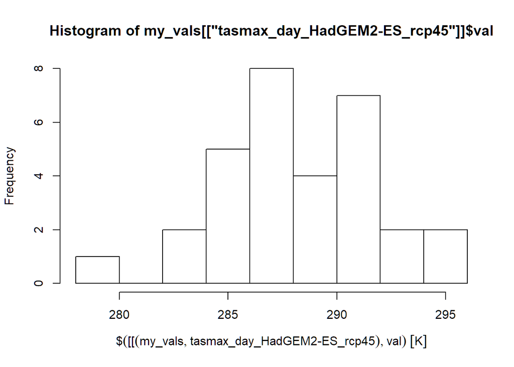

```r
hist(my_vals[["tasmax_day_HadGEM2-ES_rcp45"]]$val)
```

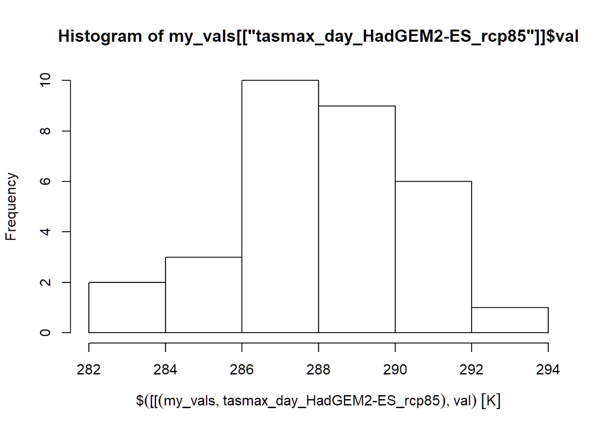

```r
hist(my_vals[["tasmax_day_HadGEM2-ES_rcp85"]]$val)
```

# Next Steps

- Expand support for `loc` argument
  - sf Polygons
  - Built-in polygon layers (e.g. Counties, Census Tracts)
  - Zip codes
  - Multiple locations

# Questions for the Team

1. Any thoughts / preferences about license? Currently using [CC0](https://creativecommons.org/publicdomain/zero/1.0/)